# Self-Driving Car Engineer Nanodegree

## Project: Build a Traffic Sign Recognition Classifier

In this notebook, a template is provided for you to implement your functionality in stages, which is required to successfully complete this project. If additional code is required that cannot be included in the notebook, be sure that the Python code is successfully imported and included in your submission if necessary.

In addition to implementing code, there is a writeup to complete. The writeup should be completed in a separate file, which can be either a markdown file or a pdf document. There is a [write up template](https://github.com/udacity/CarND-Traffic-Sign-Classifier-Project/blob/master/writeup_template.md) that can be used to guide the writing process. Completing the code template and writeup template will cover all of the [rubric points](https://review.udacity.com/#!/rubrics/481/view) for this project.

The [rubric](https://review.udacity.com/#!/rubrics/481/view) contains "Stand Out Suggestions" for enhancing the project beyond the minimum requirements. The stand out suggestions are optional. If you decide to pursue the "stand out suggestions", you can include the code in this Ipython notebook and also discuss the results in the writeup file.

> **Note:** Code and Markdown cells can be executed using the **Shift + Enter** keyboard shortcut. In addition, Markdown cells can be edited by typically double-clicking the cell to enter edit mode.

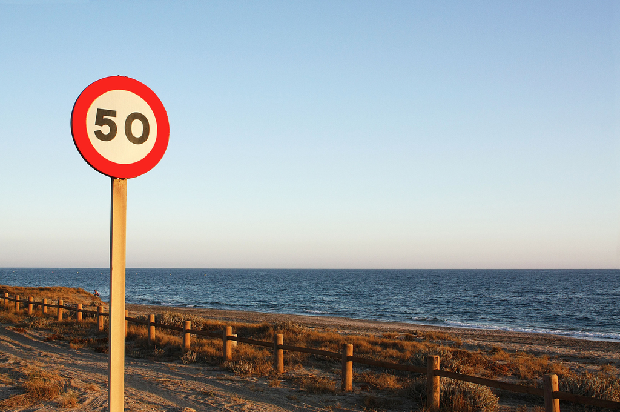

```python
from IPython.display import Image
Image(filename='sign.jpg')
```

## Step 0: Load The Data

```python
# Load pickled data
import pickle
import cv2

training_file = 'data/train.p'
validation_file= 'data/valid.p'
testing_file = 'data/test.p'

with open(training_file, mode='rb') as f:
    train = pickle.load(f)
with open(validation_file, mode='rb') as f:
    valid = pickle.load(f)
with open(testing_file, mode='rb') as f:
    test = pickle.load(f)

X_train, y_train = train['features'], train['labels']
X_valid, y_valid = valid['features'], valid['labels']
X_test, y_test = test['features'], test['labels']
```

## Step 1: Dataset Summary & Exploration

The pickled data is a dictionary with 4 key/value pairs:

- `'features'` is a 4D array containing raw pixel data of the traffic sign images, (num examples, width, height, channels).
- `'labels'` is a 1D array containing the label/class id of the traffic sign. The file `signnames.csv` contains id -> name mappings for each id.
- `'sizes'` is a list containing tuples, (width, height) representing the original width and height the image.
- `'coords'` is a list containing tuples, (x1, y1, x2, y2) representing coordinates of a bounding box around the sign in the image. **THESE COORDINATES ASSUME THE ORIGINAL IMAGE. THE PICKLED DATA CONTAINS RESIZED VERSIONS (32 by 32) OF THESE IMAGES**

Complete the basic data summary below. Use python, numpy and/or pandas methods to calculate the data summary rather than hard coding the results. For example, the [pandas shape method](http://pandas.pydata.org/pandas-docs/stable/generated/pandas.DataFrame.shape.html) might be useful for calculating some of the summary results.

### Provide a Basic Summary of the Data Set Using Python, Numpy and/or Pandas

```python
n_train = len(X_train)
n_test = len(X_test)
image_shape = X_train[0].shape
n_classes = len(set(y_train))

print("Number of training examples =", n_train)
print("Number of testing examples =", n_test)
print("Image data shape =", image_shape)
print("Number of classes =", n_classes)
```

```
Number of training examples = 34799
Number of testing examples = 12630
Image data shape = (32, 32, 3)
Number of classes = 43
```

### Include an exploratory visualization of the dataset

Visualize the German Traffic Signs Dataset using the pickled file(s). This is open ended, suggestions include: plotting traffic sign images, plotting the count of each sign, etc.

The [Matplotlib](http://matplotlib.org/) [examples](http://matplotlib.org/examples/index.html) and [gallery](http://matplotlib.org/gallery.html) pages are a great resource for doing visualizations in Python.

**NOTE:** It's recommended you start with something simple first. If you wish to do more, come back to it after you've completed the rest of the sections.

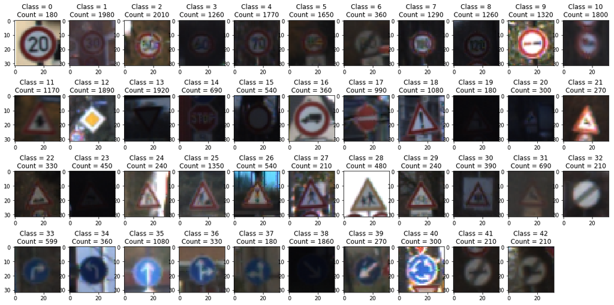

```python
import numpy as np
import matplotlib.pyplot as plt
%matplotlib inline

plt.rcParams['figure.figsize'] = (20.0, 10.0)
classes, idx = np.unique(y_train, return_index=True)
fig = plt.figure()
for i in range(len(idx)):
    ax = fig.add_subplot(4, 11, i + 1)
    ax.set_title("Class = %s\nCount = %s" %(i, len(np.where(y_train == i)[0])))
    ax.imshow(X_train[idx[i]])
plt.show()
```

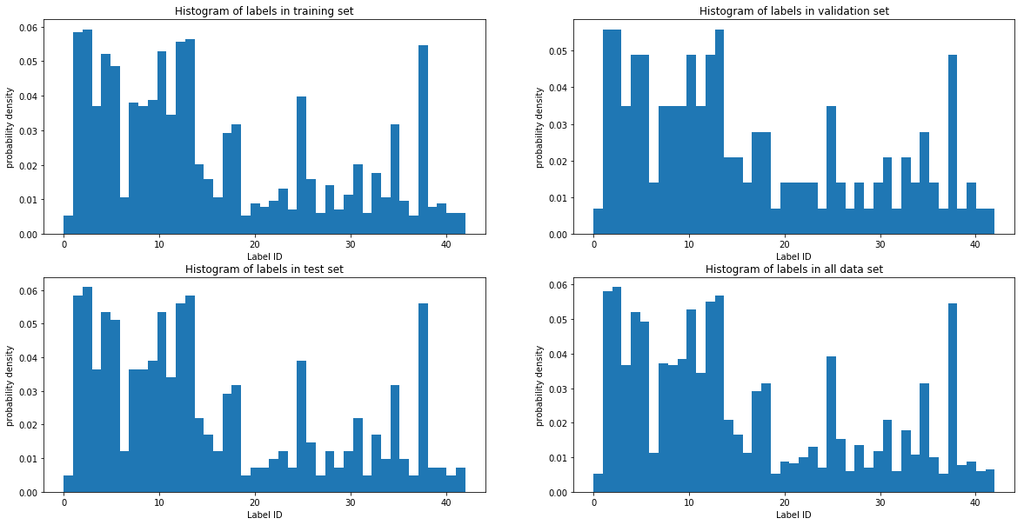

```python
%matplotlib inline

title = ['training', 'validation', 'test', 'all data']
yplot = [y_train, y_valid, y_test, np.concatenate((y_train, y_valid, y_test))]
plt.rcParams['figure.figsize'] = (20.0, 10.0)
classes, idx = np.unique(y_train, return_index=True)
fig = plt.figure()
for i in range(4):
    ax = fig.add_subplot(2, 2, i + 1)
    ax.set_title('Histogram of labels in %s set' %title[i])
    ax.set_xlabel('Label ID')
    ax.set_ylabel('probability density')
    ax.hist(yplot[i], n_classes, normed=1)
plt.savefig('bar_charts.png', format='png')
plt.show()
```

## Step 2: Design and Test a Model Architecture

Design and implement a deep learning model that learns to recognize traffic signs. Train and test your model on the [German Traffic Sign Dataset](http://benchmark.ini.rub.de/?section=gtsrb&subsection=dataset).

The LeNet-5 implementation shown in the classroom at the end of the CNN lesson is a solid starting point. You'll have to change the number of classes and possibly the preprocessing, but aside from that it's plug and play!

With the LeNet-5 solution from the lecture, you should expect a validation set accuracy of about 0.89. To meet specifications, the validation set accuracy will need to be at least 0.93. It is possible to get an even higher accuracy, but 0.93 is the minimum for a successful project submission.

There are various aspects to consider when thinking about this problem:

- Neural network architecture (is the network over or underfitting?)
- Play around preprocessing techniques (normalization, rgb to grayscale, etc)
- Number of examples per label (some have more than others).
- Generate fake data.

Here is an example of a [published baseline model on this problem](http://yann.lecun.com/exdb/publis/pdf/sermanet-ijcnn-11.pdf). It's not required to be familiar with the approach used in the paper but, it's good practice to try to read papers like these.

### Pre-process the Data Set (normalization, grayscale, etc.)

Use the code cell (or multiple code cells, if necessary) to implement the first step of your project.

```python
import os
import numpy as np
from keras.models import Sequential
from keras.layers import Activation, Dropout, Flatten, Dense
from keras.preprocessing.image import ImageDataGenerator
from keras.layers import Convolution2D, MaxPooling2D, ZeroPadding2D
from keras import optimizers
from keras.utils import np_utils
```

```python
Y_train = np_utils.to_categorical(y_train, n_classes)
Y_valid = np_utils.to_categorical(y_valid, n_classes)
Y_test = np_utils.to_categorical(y_test, n_classes)
```

```python
datagen = ImageDataGenerator(
    featurewise_center=True,
    featurewise_std_normalization=True,
    rotation_range=15,
    shear_range=0.5,
    zoom_range=0.2,
    )
datagen.fit(X_train)

datagen_v = ImageDataGenerator(
    featurewise_center=True,
    featurewise_std_normalization=True,
    rotation_range=15,
    shear_range=0.5,
    zoom_range=0.2,
    )
datagen_v.fit(X_valid)
```

### Model Architecture

```python
model = Sequential()

model.add(Convolution2D(32, 3, 3, input_shape=(32, 32, 3), activation='relu', name='conv1'))
model.add(MaxPooling2D(pool_size=(2, 2)))

model.add(Convolution2D(64, 3, 3, activation='relu', name='conv2'))
model.add(MaxPooling2D(pool_size=(2, 2)))

model.add(Convolution2D(128, 3, 3, activation='relu', name='conv3'))
model.add(MaxPooling2D(pool_size=(2, 2)))

model.add(Convolution2D(256, 1, 1, activation='relu', name='conv4'))
model.add(MaxPooling2D(pool_size=(2, 2)))

model.add(Flatten())
model.add(Dense(64, activation='relu'))
model.add(Dropout(0.65))
model.add(Dense(43, activation='sigmoid'))

model.compile(optimizer='rmsprop', loss='binary_crossentropy', metrics=['accuracy'])
```

### Train, Validate and Test the Model

A validation set can be used to assess how well the model is performing. A low accuracy on the training and validation sets imply underfitting. A high accuracy on the training set but low accuracy on the validation set implies overfitting.

```python
nb_epoch=15
model.fit_generator(datagen.flow(X_train, Y_train, batch_size=64),
                    samples_per_epoch=len(X_train),
                    nb_epoch=nb_epoch,
                    validation_data=(datagen.flow(X_valid, Y_valid, batch_size=64)),
                    nb_val_samples=len(X_valid))
```

```
<keras.callbacks.History at 0x7f319ae12080>
```

### Accuracy on test set

```python
model.evaluate_generator(datagen.flow(X_test, Y_test, batch_size=32), len(X_test))
```

```
[0.014018643371058851, 0.99583304911875481]
```

## Step 3: Test a Model on New Images

To give yourself more insight into how your model is working, download at least five pictures of German traffic signs from the web and use your model to predict the traffic sign type.

You may find `signnames.csv` useful as it contains mappings from the class id (integer) to the actual sign name.

### Load and Output the Images

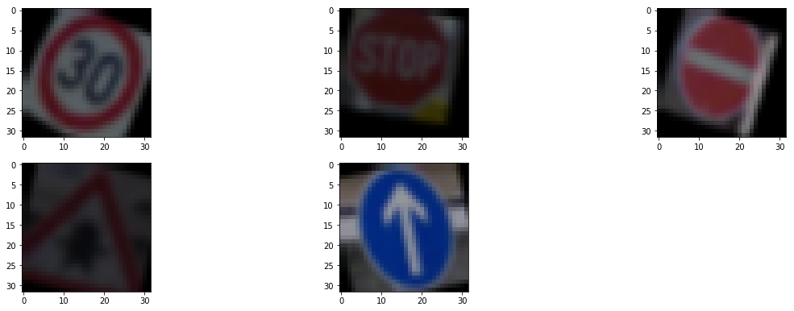

```python
import os
import random

def rotate_filter_image(image):
    kernel = np.ones((2, 2),np.float32)/4
    (h, w) = image.shape[:2]
    center = (w / 2, h / 2)
    M = cv2.getRotationMatrix2D(center, random.randint(-20,20), 1.0)
    rotated = cv2.warpAffine(image, M, (w, h))
    return cv2.filter2D(rotated, -1, kernel)

german_data = 'data/german-test/'
X_german = np.zeros(shape=(5, 32, 32, 3), dtype="uint8")
y_german = np.array([1, 14, 17, 11, 35], dtype="uint8")
Y_german = np_utils.to_categorical(y_german, n_classes)
for i, img in enumerate(sorted(os.listdir(german_data))):
    image = cv2.cvtColor(cv2.imread(german_data + img), cv2.COLOR_BGR2RGB)
    X_german[i] = rotate_filter_image(image)
    cv2.imwrite('./writeup_images/%s.png' %i, X_german[i])
    plt.subplot(330 + 1 + i)
    plt.imshow(X_german[i])
plt.show()

datagen_g = ImageDataGenerator(
    featurewise_center=True,
    featurewise_std_normalization=True,
    )
datagen_g.fit(X_german)
```

### Predict the Sign Type for Each Image

```python
print("Below are the label IDs for the above test images respectively:")
print(model.predict_classes(X_german))
```

```
Below are the label IDs for the above test images respectively:
[ 1 14 17 11 35]
```

## Analyze Performance

```python
model.evaluate(X_german, Y_german)
```

```
[8.3417078712955117e-05, 1.0]
```

### Output Top 5 Softmax Probabilities For Each Image Found on the Web

For each of the new images, print out the model's softmax probabilities to show the **certainty** of the model's predictions (limit the output to the top 5 probabilities for each image). [`tf.nn.top_k`](https://www.tensorflow.org/versions/r0.12/api_docs/python/nn.html#top_k) could prove helpful here.

The example below demonstrates how tf.nn.top_k can be used to find the top k predictions for each image.

`tf.nn.top_k` will return the values and indices (class ids) of the top k predictions. So if k=3, for each sign, it'll return the 3 largest probabilities (out of a possible 43) and the correspoding class ids.

Take this numpy array as an example. The values in the array represent predictions. The array contains softmax probabilities for five candidate images with six possible classes. `tk.nn.top_k` is used to choose the three classes with the highest probability:

```
# (5, 6) array
a = np.array([[ 0.24879643,  0.07032244,  0.12641572,  0.34763842,  0.07893497,
         0.12789202],
       [ 0.28086119,  0.27569815,  0.08594638,  0.0178669 ,  0.18063401,
         0.15899337],
       [ 0.26076848,  0.23664738,  0.08020603,  0.07001922,  0.1134371 ,
         0.23892179],
       [ 0.11943333,  0.29198961,  0.02605103,  0.26234032,  0.1351348 ,
         0.16505091],
       [ 0.09561176,  0.34396535,  0.0643941 ,  0.16240774,  0.24206137,
         0.09155967]])
```

Running it through `sess.run(tf.nn.top_k(tf.constant(a), k=3))` produces:

```
TopKV2(values=array([[ 0.34763842,  0.24879643,  0.12789202],
       [ 0.28086119,  0.27569815,  0.18063401],
       [ 0.26076848,  0.23892179,  0.23664738],
       [ 0.29198961,  0.26234032,  0.16505091],
       [ 0.34396535,  0.24206137,  0.16240774]]), indices=array([[3, 0, 5],
       [0, 1, 4],
       [0, 5, 1],
       [1, 3, 5],
       [1, 4, 3]], dtype=int32))
```

Looking just at the first row we get `[ 0.34763842, 0.24879643, 0.12789202]`, you can confirm these are the 3 largest probabilities in `a`. You'll also notice `[3, 0, 5]` are the corresponding indices.

```python
probabilities = model.predict(X_german)

print("Top 5 Softmax Probabilities For Each Image:")
for p in probabilities:
    print(sorted(p, reverse=True)[:5])

print("\nCorresponding Image class:")
for p in probabilities:
    print(sorted(range(len(p)), key=lambda k: p[k], reverse=True)[:5])
```

```
Top 5 Softmax Probabilities For Each Image:
[0.99886715, 1.1138817e-19, 3.2561287e-36, 0.0, 0.0]
[0.98344165, 0.0, 0.0, 0.0, 0.0]
[1.0, 0.0, 0.0, 0.0, 0.0]
[0.99991703, 2.0257838e-09, 7.55653e-21, 4.2894068e-33, 2.4159068e-33]
[1.0, 0.0, 0.0, 0.0, 0.0]

Corresponding Image class:
[1, 0, 2, 3, 4]
[14, 0, 1, 2, 3]
[17, 0, 1, 2, 3]
[11, 30, 3, 5, 27]
[35, 0, 1, 2, 3]
```

## Step 4: Visualize the Neural Network's State with Test Images

This Section is not required to complete but acts as an additional excersise for understaning the output of a neural network's weights. While neural networks can be a great learning device they are often referred to as a black box. We can understand what the weights of a neural network look like better by plotting their feature maps. After successfully training your neural network you can see what it's feature maps look like by plotting the output of the network's weight layers in response to a test stimuli image. From these plotted feature maps, it's possible to see what characteristics of an image the network finds interesting. For a sign, maybe the inner network feature maps react with high activation to the sign's boundary outline or to the contrast in the sign's painted symbol.

Provided for you below is the function code that allows you to get the visualization output of any tensorflow weight layer you want. The inputs to the function should be a stimuli image, one used during training or a new one you provided, and then the tensorflow variable name that represents the layer's state during the training process, for instance if you wanted to see what the LeNet lab's feature maps looked like for it's second convolutional layer you could enter conv2 as the tf_activation variable.

For an example of what feature map outputs look like, check out NVIDIA's results in their paper [End-to-End Deep Learning for Self-Driving Cars](https://devblogs.nvidia.com/parallelforall/deep-learning-self-driving-cars/) in the section Visualization of internal CNN State. NVIDIA was able to show that their network's inner weights had high activations to road boundary lines by comparing feature maps from an image with a clear path to one without. Try experimenting with a similar test to show that your trained network's weights are looking for interesting features, whether it's looking at differences in feature maps from images with or without a sign, or even what feature maps look like in a trained network vs a completely untrained one on the same sign image.

[figure not shown]

Your output should look something like this (above)

```python
from keras import backend as K

def get_activations(model, layer_idx, X_batch):
    get_activations = K.function([model.layers[0].input, K.learning_phase()], [model.layers[layer_idx].output,])
    activations = get_activations([X_batch,0])
    return activations

def outputFeatureMap(image_input, layer, model, activation_min=-1, activation_max=-1 ,plt_num=1):
    activation = get_activations(model, layer, np.reshape(image_input, (1, 32, 32, 3)))[0][0]
    featuremaps = activation.shape[2]
    plt.figure(plt_num, figsize=(15,15))
    for featuremap in range(featuremaps):
        plt.subplot(6,8, featuremap+1) # sets the number of feature maps to show on each row and column
        plt.title('FeatureMap ' + str(featuremap)) # displays the feature map number
        if activation_min != -1 & activation_max != -1:
            plt.imshow(activation[:,:, featuremap], interpolation="nearest", vmin =activation_min, vmax=activation_max, cmap="gray")
        elif activation_max != -1:
            plt.imshow(activation[:,:, featuremap], interpolation="nearest", vmax=activation_max, cmap="gray")
        elif activation_min !=-1:
            plt.imshow(activation[:,:, featuremap], interpolation="nearest", vmin=activation_min, cmap="gray")
        else:
            plt.imshow(activation[:,:, featuremap], interpolation="nearest", cmap="gray")
```

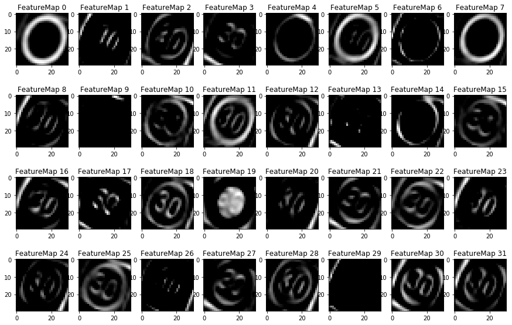

```python
# output of First convolution layer : "conv1"
outputFeatureMap(X_german[0], 0, model)
```

### Question 9

Discuss how you used the visual output of your trained network's feature maps to show that it had learned to look for interesting characteristics in traffic sign images

**Answer:** Figure above shows 32 feature maps from the first convolutional layer that are looking for edges of outer circle, number 3, and number 0 of the traffic sign. Each feature map has a different brighter region, indicating that each of them are looking for differently oriented edges. Feature maps 0, 5, and 7 are looking for outer circle edges. Feature maps 17, 20, and 23 looking for edges of number 3 and number 0. Feature map 28 and feature map 30 are complements of each other where both are extracting the contrast between the background and foreground of the traffic sign. This shows that the network has learned to look for interesting charecterstics of a traffic sign.